# ESM_204_Assignment_3

Sage Davis and Jack Miller

May 7, 2022

```r
library(tidyverse)
library(rootSolve)
library(janitor)
library(tibble)
model_dem_low <-lm(price_cents ~ q_low_kwh, data = df)
model_dem_high <-lm(price_cents ~ q_high_kwh, data = df)
```

Need to rearrange the parameter to get Q(P)!

Qgg = Qlow(P) + Qlow(P)

Importantly, since they-intercepts are different, we know that Qagg(P) will have a kink. ifelse() statement will take care of the kink.

Define a function to get demand in terms of Q

```r
demand <-function(p, model){
  q <- (p - model$coefficients[[1]])/model$coefficients[[2]]
  q <- ifelse(q<0,0,q)
  return(q)}

demand_l_2 <- demand(p=2, model = model_dem_low)

demand_h_2 <- demand(p=2, model = model_dem_high)
```

```r
# for each p level, return estimated aggregate demand
demand_agg <- function(p){
  q <- demand(p, model_dem_low) + demand(p, model_dem_high)
  return(q)}
```

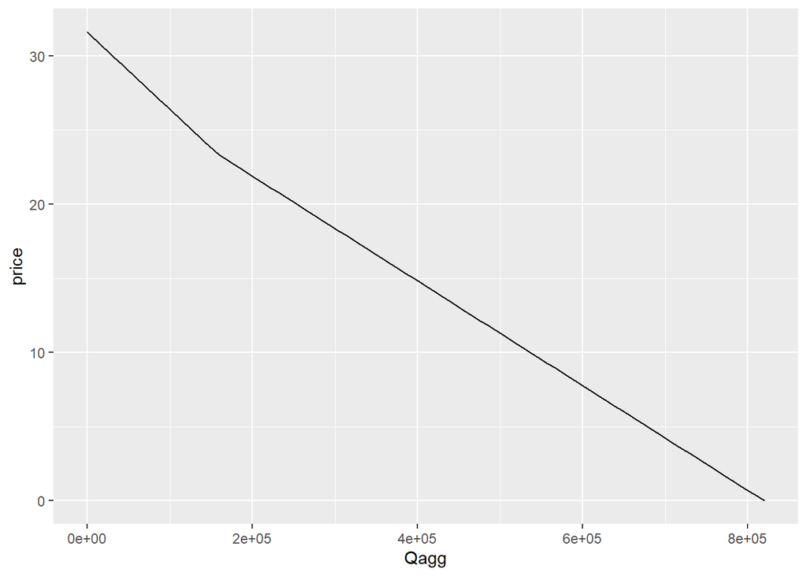

```r
price = seq(0, model_dem_high$coefficient[1], length.out = 100)
Qagg <- map(price, demand_agg) %>%
  unlist()

df<- tibble(Qagg = Qagg, price = price)

ggplot(df, aes(Qagg, price)) +
  geom_line()
```

# I also define functions for calculating the consumer surplus:

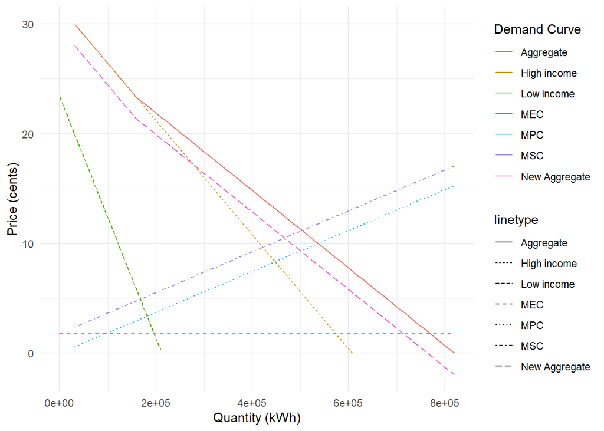

```r
#demand function
demand <- function(p, model){
  q <- (p - model$coefficients[[1]])/model$coefficients[[2]]
  q <- ifelse(q<0,0,q)
  return(q)
}
#aggregate demand
demand_agg <- function(p){
  q <- demand(p, model_dem_low) + demand(p, model_dem_high)
  return(q)
}
#price vector
price = seq(0, 30, length.out = 100)

#applying the aggregate demand function to the price vector
Qagg <- map(price, demand_agg) %>% unlist()

#making the new dataframe with Qagg and price
agg_data<- tibble(Qagg = Qagg, price = price)

#making predicted dataframes with low and high models
l_pred <- tibble(price = price,
                 demand = demand(price, model_dem_low))
l_pred[l_pred == 0] <- NA
h_pred <- tibble(price = price,
                 demand = demand(price, model_dem_high))
#MPC line
qfm <- demand_agg(10)
MPC_slope <- 10/qfm
supply <- function(q){
  p <- MPC_slope * q
  return(p)
}
MPC <- tibble(price = supply(agg_data$Qagg),
              demand = agg_data$Qagg)

# Price of CO2 per lb, 1MT = 2204.62 lb,  $51 per MT of CO2

mt_lb <- 2204.62    # Metric Ton (MT) in lbs

P_lbco2 <- 51*mt_lb   # CO2 - price per lb ($/lb)

C_emit_per_kwh <- 0.85     # 1kWh = 0.85lb CO2, 0.85lb/kWh

#  will need this MEC function in #4

mec_f <- function(SCC) {              #  cents/kWh = ($/MT / (lb/MT)  * lb/kWh) * 100
  round((SCC / mt_lb * C_emit_per_kwh) * 100, 3)

}

mec51 <- mec_f(51)   # SCC = $51 per MT

#graph changes in demand
Dagg_new <- agg_data - mec51

low_dem_new <- l_pred - mec51

high_dem_new <- h_pred - mec51

#plot
ggplot() +
  geom_line(agg_data, mapping = aes(x = Qagg, y = price, color = "Aggregate", lty = "Aggregate")) +
  geom_line(l_pred, mapping = aes(x = demand, y = price, color = "Low income", lty = "Low income")) +
  geom_line(h_pred, mapping = aes(x = demand, y = price, color = "High income", lty = "High income")) +
  geom_line(Dagg_new, mapping = aes(x = Qagg, y= price, color = "New Aggregate", lty = "New Aggregate")) +
  geom_line(MPC, mapping = aes(x = demand, y = price, color = "MPC", lty = "MPC")) +
  geom_segment(aes(x = 0, y = 1.8, xend = 819713.75, yend = 1.8, color = "MEC", lty = "MEC")) +
  geom_line(MPC, mapping = aes(x = demand, y = price + 1.8, color = "MSC", lty = "MSC")) +
  labs(x = "Quantity (kWh)",
       y = "Price (cents)",
       color = "Demand Curve") +
  theme_minimal()
```

#### The MEC is 1.966 cents per Kwh electricity

# –

#2. What is the aggregate monthly demand curve for electricity? What is the supply curve for electricity? What is the “benefit” to consumers under the status quo? What is the “benefit” to producers under the status quo? What is the environmental cost under the status quo?

```r
# ASSUMING STATUS QUO IS WITH NOT MEC APPLIED - DO WE AGREE?
#I agree! But does it make sense to have the status quo be BAU (0.85Q)?

# P = mQ + b

ml <- model_dem_low$coefficient[2]  # slope of DL
bl <- model_dem_low$coefficient[1]  # P int of DL

mh <- model_dem_high$coefficient[2]  # slope of DH
bh <- model_dem_high$coefficient[1]  # P int of DH

# P = mQ + b
# Q = P/m - b/m
# Ql = P/ml - bl/ml , Qh = P/mh - bh/mh
# Q = P/ml + P/mh - bl/ml - bh/mh
# Q = P*(ml + mh)/(ml*mh) - (bl/ml + bh/mh)
# Q = Sagg * P - Qint for Q > Qh_k

Sagg <- (ml + mh)/(ml*mh)  # Slope of Qagg, Q > Qh_k
Magg <- 1/Sagg             # Slope of Dagg, Q > Qh_k
Qint <- -(bl/ml + bh/mh)  # Neg?  Only works this way

# find Q at kink in Dagg at dem_low intercept (P = bl)
# P = dem_high = bl = mhQh_k + bh
# Qh_k = (bl - bh)/mh


Qh_k <- (bl - bh)/mh     # kink point of Dagg

# Q <- Sagg * P - Qint

# Dagg = P from above, P = (Q + Qint)/Sagg = (Magg)*(Q + Qint)

# Dagg <- Magg*(Q + Qint)

Dagg_d <- tibble(Q = seq(round(Qh_k, 0), Qint, 100))

Dagg_d <- Dagg_d %>%
  mutate(price = Magg*(Q - Qint))

Dagg <- lm(price ~ Q, data = Dagg_d)  # Linear regression for Dagg(P) for Q > 158,329

P_e <- 10    # current price of electricity in cents

# Supply (MPC) goes thru P_e at Dagg and origin using Qagg = Sagg * P + Qint.
# Q_p_e is the run (Q) and P_e is the rise (P) for MPC, Oint = 0.

Q_p_e <- Sagg*P_e + Qint   # Plug P-e into above equation to get intersection Q point

m_MPC <- P_e / Q_p_e    # Slope of Supply (MPC)

MPC_d <- tibble(Q = seq(0, Qint, 100))   # MPC data

MPC_d <- MPC_d %>%
  mutate (price = m_MPC * Q)

MPC <- lm(price ~ Q, data = MPC_d)  # MPC Linear regression

MPC
```

```
##
## Call:
## lm(formula = price ~ Q, data = MPC_d)
##
## Coefficients:
## (Intercept)            Q
##  -3.641e-14    1.863e-05
```

```r
CS <- function(p, model){
  q <- demand(p, model)
  cs <- 0.5*(model$coefficients[[1]] - p)*q
  return(cs)}

CS_agg <- function(p){
  cs <- CS(p,model_dem_low) + CS(p,model_dem_high)
  return(cs)}


CS_agg_sq <-CS_agg(10)  # current price is 10 cents


PS <- function(p, model){
  q <- demand(p, model)
  ps <- 0.5 * p * q
  return(ps)}

PS_agg <- function (p){
  ps <- PS(p,model_dem_low) + PS(p,model_dem_high)
  return(ps)}

PS_sq <- PS(10, Dagg)

PS_agg_sq <- PS_agg(10)

EC <- function(p, model){    # Total Environmental Cost
  q <- demand(p, model)
  ec <- p * q
  return(ec)}

EC_sq <- EC(mec51, Dagg)
```

#### Aggregate Demand Curve:

#### Dagg = -5^{-5}*Q + 31.6 for Q < 1.5832875^{5}

#### Dagg = -4^{-5}*Q + 29 for Q > 1.5832875^{5}

#### Current supply curve: MPC = 2^{-5}*Q + 0

#### Consumer Benefit: 5.298722^{6}

#### Producer Benefit: 2.683597^{6}

#### Environmental cost: 1.502176^{6}

#–

#3. How is the current consumer benefit divided between “high” and “low” income consumers?

```r
CS_l_sq <- CS(10, model_dem_low)  # consumer benefit to low income

CS_h_sq <- CS(10, model_dem_high)

CS_l_p <- (CS_l_sq / CS_agg_sq) * 100   # Percent benefit to low income

CS_h_p <- (CS_h_sq / CS_agg_sq) * 100
```

#### Consumer Benefit Split: 15.3% Low & 84.7% High

# –

#4. Derive the optimal electricity tax (in cents per kWh) using the interim SCC. Noting that recent research has shown the poor face a disproportionate share of the impacts from climate change, assume that the climate externality is borne entirely by the “low” income group. What would be the effects of this tax on:

#(a) The amount of electricity produced and consumed

```r
Qtax <- function(mec){
  q <- (Dagg$coefficient[1] - mec) / (m_MPC - Magg)
  return(q)
}

Qtax51 <- Qtax(mec51)
Qtax51
```

```
## (Intercept)
##    500290.5
```

#(b) The price of electricity

```r
Ptax <- function(q){
  p <- ((Qtax51 * m_MPC) + mec51)
  return(p)
}
Ptax51 <- Ptax(Qtax51)
Ptax51
```

```
## (Intercept)
##    11.28727
```

#### The price of electricity is 11.287267

#(c) Overall welfare of “high” income consumers

```r
#  Why is this here?
new_model_dem_low <-lm(price ~ demand, data = low_dem_new)
new_model_dem_high <-lm(price ~ demand, data = high_dem_new)

CS <- function(p, model){
  q <- demand(p, model)
  cs <- 0.5*(model$coefficients[[1]] - p)*q
  return(cs)}

CS_new_high <- CS(Ptax51, new_model_dem_high)

CS_new_high
```

```
## (Intercept)
##     3237848
```

# Graph the demand curves and the aggregate in one graph with the MES, MSC, and MPC

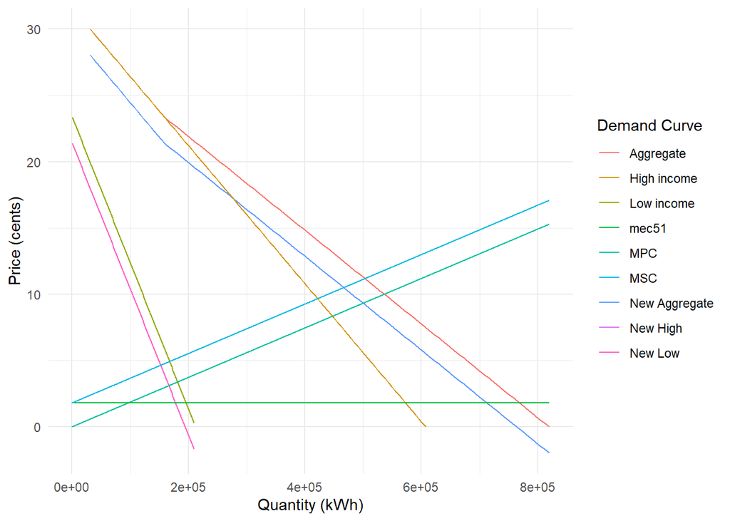

```r
ggplot() +
  geom_line(low_dem_new, mapping = aes(x = demand, y= price, color = "New Low")) +
  geom_line(Dagg_new, mapping = aes(x = Qagg, y= price, color = "New Aggregate")) +
  geom_line(h_pred, mapping = aes(x = demand, y= price, color = "New High"))+
   geom_line(agg_data, mapping = aes(x = Qagg, y = price, color = "Aggregate")) +
  geom_line(l_pred, mapping = aes(x = demand, y = price, color = "Low income")) +
  geom_line(h_pred, mapping = aes(x = demand, y = price, color = "High income")) +
  geom_line(MPC, mapping = aes(x = Q, y = price, color = "MPC")) +
  geom_segment(aes(x = 0, y = 1.8, xend = 819713.75, yend = 1.8, color = "mec51")) +
  geom_line(MPC, mapping = aes(x = Q, y = price + 1.8, color = "MSC")) +
  labs(x = "Quantity (kWh)",
       y = "Price (cents)",
       color = "Demand Curve") +
  theme_minimal()
```

#(d) Overall welfare of “low” income consumers

```r
CS_new_low <- CS(Ptax51, new_model_dem_low)

CS_new_low
```

```
## (Intercept)
##    464483.6
```

#### The overall welfare of low income consumers will decrease with the addition of the tax

#(e) Power suppliers (i.e., electricity producers) producer surplus

```r
PS <- function(p, model){
  q <- demand(p, model)
  ps <- 0.5 * p * q
  return(ps)}

PS_agg <- function (p){
  ps <- PS(p,model_dem_low) + PS(p,model_dem_high)
  return(ps)}

Dagg_new <-function(p, model){
  q <- (p - model$coefficients[[1]])/model$coefficients[[2]] - mec51
  q <- ifelse(q<0,0,q)
  return(q)}

Dagg_new_d <- tibble(Qagg = Qagg, price = price)

PS_new <- function(p, model){
  q <- Dagg_new(p, model)
  ps <- 0.5 * p* q
  return(ps)}
```

```r
PS_new_high <- PS_new(Ptax51, model_dem_high)

PS_new_low <- PS_new(Ptax51, model_dem_low)
```

```r
PS_total_new <- PS_new_low + PS_new_high

PS_total_new
```

```
## (Intercept)
##     2823434
```

#### The welfare benefit to electricity producers is 2.8234343^{6}

#(f) Total environmental damage (mec51 x Qtax51)

```r
Env_damage <- Qtax51 * mec51
```

#### Total environmental damage is equal to 9.8357122^{5}

#(g) Total tax revenue generated

```r
Tax_rev <- Qtax51 * mec51
```

#### Tax revenue is equal to 9.8357122^{5}

#–

### 5. Now, assume that all revenue from the electricity tax will be redistributed to the consumers in proportion to their pre-tax consumption. For example, if 80% of the electricity was consumed by “high” income consumers, then they get 80% of the tax revenue. Additionally, consider the fact that current scientific evidence suggests the true SCC may be much higher than $51. For a range of SCC values ($51, $75, $100, $125, and $150 per metric ton of CO2), calculate the effects of an SCC-based electricity tax on:

```r
# function to calculate Low Demand at different MECs
LowD <- function(mec) {
  Low_D <- l_pred %>%
  mutate(price = price - mec)
  lm(price ~ demand, data = Low_D)      # put in function, so have no data table
}

# function to calculate High Demand at different MECs
HighD <- function(mec) {
  High_D <- h_pred %>%
  mutate(price = price - mec)
  lm(price ~ demand, data = High_D)      # put in function, so have no data table
}



#  MAYBE CALULATE Qtax## and Ptax## Here

mec75 <- mec_f(75)    # maybe these two functions can be combined?
Qtax <- function(mec){
  q <- (Dagg$coefficient[1] - mec) / (m_MPC - Magg)
  return(q)
}

Qtax75 <- Qtax(mec75)
Qtax75
```

```
## (Intercept)
##    483132.3
```

```r
Ptax <- function(q){
  p <- ((Qtax75 * m_MPC) + mec75)
  return(p)
}
Ptax75 <- Ptax(Qtax75)
Ptax75
```

```
## (Intercept)
##    11.89358
```

```r
mec100 <- mec_f(100)
Qtax <- function(mec){
  q <- (Dagg$coefficient[1] - mec) / (m_MPC - Magg)
  return(q)
}

Qtax100 <- Qtax(mec100)
Qtax100
```

```
## (Intercept)
##    465269.9
```

```r
Ptax <- function(q){
  p <- ((Qtax100 * m_MPC) + mec100)
  return(p)
}
Ptax100 <- Ptax(Qtax100)
Ptax100
```

```
## (Intercept)
##    12.52477
```

```r
mec125 <- mec_f(125)
Qtax <- function(mec){
  q <- (Dagg$coefficient[1] - mec) / (m_MPC - Magg)
  return(q)
}

Qtax125 <- Qtax(mec125)
Qtax125
```

```
## (Intercept)
##      447426
```

```r
Ptax <- function(q){
  p <- ((Qtax125 * m_MPC) + mec125)
  return(p)
}
Ptax125 <- Ptax(Qtax125)
Ptax125
```

```
## (Intercept)
##    13.15531
```

```r
mec150 <- mec_f(150)
Qtax <- function(mec){
  q <- (Dagg$coefficient[1] - mec) / (m_MPC - Magg)
  return(q)
}

Qtax150 <- Qtax(mec150)
Qtax150
```

```
## (Intercept)
##    429563.6
```

```r
Ptax <- function(q){
  p <- ((Qtax150 * m_MPC) + mec150)
  return(p)
}
Ptax150 <- Ptax(Qtax150)
Ptax150
```

```
## (Intercept)
##     13.7865
```

```r
LowD51 <- LowD(mec51)

HighD51 <- HighD(mec51)

CS_h51 <- CS(Ptax51, HighD51)


LowD75 <- LowD(mec75)

HighD75 <- HighD(mec75)

CS_h75 <- CS(Ptax75, HighD75)


LowD100 <- LowD(mec100)

HighD100 <- HighD(mec100)

CS_h100 <- CS(Ptax100, HighD100)


LowD125 <- LowD(mec125)

HighD125 <- HighD(mec125)

CS_h125 <- CS(Ptax125, HighD125)



LowD150 <- LowD(mec150)

HighD150 <- HighD(mec150)

CS_h150 <- CS(Ptax150, HighD150)
```

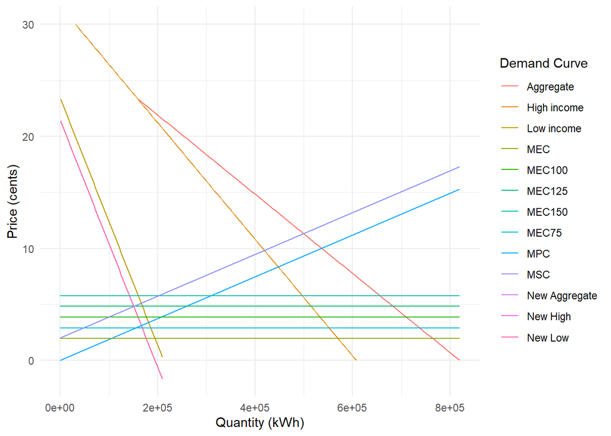

```r
ggplot() +
  geom_line(low_dem_new, mapping = aes(x = demand, y= price, color = "New Low")) +
  geom_line(Dagg_new_d, mapping = aes(x = Qagg, y= price, color = "New Aggregate")) +
  geom_line(h_pred, mapping = aes(x = demand, y= price, color = "New High"))+
   geom_line(agg_data, mapping = aes(x = Qagg, y = price, color = "Aggregate")) +
  geom_line(l_pred, mapping = aes(x = demand, y = price, color = "Low income")) +
  geom_line(h_pred, mapping = aes(x = demand, y = price, color = "High income")) +
  geom_line(MPC_d, mapping = aes(x = Q, y = price, color = "MPC")) +
  geom_segment(aes(x = 0, y = 1.966, xend = 819713.75, yend = 1.966, color = "MEC")) +
  geom_segment(aes(x = 0, y = 3.856, xend = 819713.75, yend = 3.856, color = "MEC100"))+
  geom_segment(aes(x = 0, y = 4.819, xend = 819713.75, yend = 4.819, color = "MEC125"))+
  geom_segment(aes(x = 0, y = 5.783, xend = 819713.75, yend = 5.783, color = "MEC150"))+
  geom_segment(aes(x = 0, y = 2.892, xend = 819713.75, yend = 2.892, color = "MEC75"))+
  geom_line(MPC_d, mapping = aes(x = Q, y = price + 2, color = "MSC")) +
  labs(x = "Quantity (kWh)",
       y = "Price (cents)",
       color = "Demand Curve") +
  theme_minimal()
```

# The tax should be where the MEC meets the Q star (socially optimal quantity). In this case, the MEC is a straight, horizontal line, so the t star will simply equal around 2 cents per Kwh electricity.

## Step 1: graph demand curves (see above)

### (a) Overall welfare of “high” income consumers

new CS for high income consumers

```r
# high welfare for SCC = 51, will need to calculate Qtax for each


CS_H51 <- CS(mec51, HighD51)  # P = mec and model at High Demand at SCC = 51

PtaxR_H51 <- (demand(P_e, model_dem_high)/Q_p_e) * (mec51 * Qtax51)  # (pretax use %)*Tax Revenue (SCC = 51)

welfareH51 <- CS_H51 + PtaxR_H51



CS_H75 <- CS(mec75, HighD75)  # P = mec and model at High Demand at SCC = 75

PtaxR_H75 <- (demand(P_e, model_dem_high)/Q_p_e) * (mec75 * Qtax75)  # (pretax use %)*Tax Revenue (SCC = 75)

welfareH75 <- CS_H75 + PtaxR_H75



CS_H100 <- CS(mec100, HighD100)  # P = mec and model at High Demand at SCC = 100

PtaxR_H100 <- (demand(P_e, model_dem_high)/Q_p_e) * (mec100 * Qtax100)  # (pretax use %)*Tax Revenue (SCC = 100)

welfareH100 <- CS_H100 + PtaxR_H100



CS_H125 <- CS(mec125, HighD125)  # P = mec and model at High Demand at SCC = 125

PtaxR_H125 <- (demand(P_e, model_dem_high)/Q_p_e) * (mec125 * Qtax125)  # (pretax use %)*Tax Revenue (SCC = 125)

welfareH125 <- CS_H125 + PtaxR_H125



CS_H150 <- CS(mec150, HighD150)  # P = mec and model at High Demand at SCC = 150

PtaxR_H150 <- (demand(P_e, model_dem_high)/Q_p_e) * (mec150 * Qtax150)  # (pretax use %)*Tax Revenue (SCC = 150)

welfareH150 <- CS_H150 + PtaxR_H150
```

#### Overall Welfare for High Incpome Comsumers:

#### Scc = 51: 8.1231032^{6}

#### Scc = 75: 7.4908836^{6}

#### Scc = 100: 6.8766441^{6}

#### Scc = 125: 6.3077795^{6}

#### Scc = 150: 5.7831083^{6}

### (b) Overall welfare of “low” income consumers

Code in demand change for each MEC and from there use low CS functions with each demand model to get your answer

```r
# low welfare for SCC = 51, will need to calculate Qtax for each

CS_L51 <- CS(mec51, LowD51)  # P = mec and model at High Demand at SCC = 51

PtaxR_L51 <- (demand(P_e, model_dem_low)/Q_p_e) * (mec51 * Qtax51)  # (pretax use %)*Tax Revenue (SCC = 51)

Burden_L51 <- mec51 * Qtax51   # low income bears the environmental burden like in 4

welfareL51 <- CS_L51 + PtaxR_L51 - Burden_L51



CS_L75 <- CS(mec75, LowD75)  # P = mec and model at High Demand at SCC = 75

PtaxR_L75 <- (demand(P_e, model_dem_low)/Q_p_e) * (mec75 * Qtax75)  # (pretax use %)*Tax Revenue (SCC = 75)

Burden_L75 <- mec75 * Qtax75   # low income bears the environmental burden like in 4

welfareL75 <- CS_L75 + PtaxR_L75 - Burden_L75



CS_L100 <- CS(mec100, LowD100)  # P = mec and model at High Demand at SCC = 100

PtaxR_L100 <- (demand(P_e, model_dem_low)/Q_p_e) * (mec100 * Qtax100)  # (pretax use %)*Tax Revenue (SCC = 100)

Burden_L100 <- mec100 * Qtax100   # low income bears the environmental burden like in 4

welfareL100 <- CS_L100 + PtaxR_L100 - Burden_L100



CS_L125 <- CS(mec125, LowD125)  # P = mec and model at High Demand at SCC = 125

PtaxR_L125 <- (demand(P_e, model_dem_low)/Q_p_e) * (mec125 * Qtax125)  # (pretax use %)*Tax Revenue (SCC = 125)

Burden_L125 <- mec125 * Qtax125   # low income bears the environmental burden like in 4

welfareL125 <- CS_L125 + PtaxR_L125 - Burden_L125



CS_L150 <- CS(mec150, LowD150)  # P = mec and model at High Demand at SCC = 150

PtaxR_L150 <- (demand(P_e, model_dem_low)/Q_p_e) * (mec150 * Qtax150)  # (pretax use %)*Tax Revenue (SCC = 150)

Burden_L150 <- mec150 * Qtax150   # low income bears the environmental burden like in 4

welfareL150 <- CS_L150 + PtaxR_L150 - Burden_L150
```

#### Scc = 51: 9.5343427^{5}

#### Scc = 75: 3.2215438^{5}

#### Scc = 100: -2.7583459^{5}

#### Scc = 125: -8.129104^{5}

#### Scc = 150: -1.2901885^{6}

#### (c) Electricity producers

Code in demand change for each MEC and from there use PS functions with each demand model to get your answer

```r
# Will need to calculate Ptax for each SCC - Looks like their benefit stays the same even with the customers paying more due to tax.

# For SCC = 51, copy and paste for other SCCs

PS_H51 <- PS_new(Ptax51, model_dem_high)

PS_L51 <- PS_new(Ptax51, model_dem_low)


PS_Agg_51 <- PS_new_low + PS_new_high  # Total benefit to Electric producers
PS_Agg_51 <- PS_H51 + PS_L51


PS_H75 <- PS_new(Ptax75, model_dem_high)

PS_L75 <- PS_new(Ptax75, model_dem_low)


PS_Agg_75 <- PS_new_low + PS_new_high  # Total benefit to Electric producers
PS_Agg_75 <- PS_H75 + PS_L75


PS_H100 <- PS_new(Ptax100, model_dem_high)

PS_L100 <- PS_new(Ptax100, model_dem_low)

PS_Agg_100 <- PS_new_low + PS_new_high
PS_Agg_100 <- PS_H100 + PS_L100


PS_H125 <- PS_new(Ptax125, model_dem_high)

PS_L125 <- PS_new(Ptax125, model_dem_low)


PS_Agg_125 <- PS_new_low + PS_new_high
PS_Agg_125 <- PS_H125 + PS_L125



PS_H150 <- PS_new(Ptax150, model_dem_high)

PS_L150 <- PS_new(Ptax150, model_dem_low)


PS_Agg_150 <- PS_new_low + PS_new_high
PS_Agg_150 <- PS_H150 + PS_L150
```